# Data Knowledge and Quality Lab Report

### Ahmed Tchagnaou

We used the python programming language for this lab. We used existing libraries such as [pandas](https://pandas.pydata.org/), [numpy](https://numpy.org/) and others to perform all the tasks. We wrote a small module called *kyd* which stands for "**Know Your Data**" with the libraries mentioned before to create specific methods related to our lab. The module code source can be found in the folder of this report.

## Dataset

We have used *Fatal Encouters* database for this lab  
The Fatal Encounters database documents non-police deaths that occur when police are present or are precipitated by police action or presence. It documents all available records for all 50 states of USA, back to 2000.

We are going to import the **kyd** module and read the dataset

```python
# Importing the kyd module
import kyd
import numpy as np
%matplotlib inline
```

```python
# Read the first sheet of the dataset and preview the first three (3) rows
data = kyd.read_data('fatal-encounters.xlsx')
data.head(3)
```

|  | Unique ID | Subject's name | Subject's age | Subject's gender | Subject's race | Subject's race with imputations | Imputation probability | URL of image of deceased | Date of injury resulting in death (month/day/year) | Location of injury (address) | ... | A brief description of the circumstances surrounding the death | Dispositions/Exclusions INTERNAL USE, NOT FOR ANALYSIS | Intentional Use of Force (Developing) | Link to news article or photo of official document | Symptoms of mental illness? INTERNAL USE, NOT FOR ANALYSIS | Video | Date&Description | Unique ID formula | Unique identifier (redundant) | Date (Year) |
| --- | --- | --- | --- | --- | --- | --- | --- | --- | --- | --- | --- | --- | --- | --- | --- | --- | --- | --- | --- | --- | --- |
| 0 | 25746.0 | Samuel H. Knapp | 17 | Male | European-American/White | European-American/White | Not imputed | NaN | 2000-01-01 | 27898-27804 US-101 | ... | Samuel Knapp was allegedly driving a stolen ve... | Unreported | Pursuit | https://drive.google.com/file/d/10DisrV8K5ReP1... | No | NaN | 1/1/2000: Samuel Knapp was allegedly driving a... | NaN | 25746.0 | 2000 |
| 1 | 25747.0 | Mark A. Horton | 21 | Male | African-American/Black | African-American/Black | Not imputed | NaN | 2000-01-01 | Davison Freeway | ... | Two Detroit men killed when their car crashed ... | Unreported | Pursuit | https://drive.google.com/file/d/1-nK-RohgiM-tZ... | No | NaN | 1/1/2000: Two Detroit men killed when their ca... | NaN | 25747.0 | 2000 |
| 2 | 25748.0 | Phillip A. Blurbridge | 19 | Male | African-American/Black | African-American/Black | Not imputed | NaN | 2000-01-01 | Davison Freeway | ... | Two Detroit men killed when their car crashed ... | Unreported | Pursuit | https://drive.google.com/file/d/1-nK-RohgiM-tZ... | No | NaN | 1/1/2000: Two Detroit men killed when their ca... | NaN | 25748.0 | 2000 |

3 rows × 29 columns

```python
# Read the second sheet of the dataset and preview the first three (3) rows
data_states = kyd.read_data('fatal-encounters.xlsx', sheet=1)
data_states.head(3)
```

|  | Abbreviation | Name | Unnamed: 2 | Population (2015 est.) | Population (2010) | Population (2005) | Population (2000) | Unnamed: 7 | NaN |
| --- | --- | --- | --- | --- | --- | --- | --- | --- | --- |
| 0 | AL | Alabama | State | 4858979 | 4822023 | 4557808 | 4452339 | Source: | US Census Bureau |
| 1 | AK | Alaska | State | 738432 | 731449 | 663661 | 627500 | Link: | https://www.census.gov/programs-surveys/popest... |
| 2 | AZ | Arizona | State | 6828065 | 6553255 | 5939292 | 5165993 | NaN | NaN |

## Data Profiling

In this section, we will show the data profiling results and indicate concerned data quality problems

```python
kyd.data_shape(data)
```

```
Data shape
Examples (lines) : 28717
Variables (columns) : 29
```

### Overview

Let's print some basic info of the dataset

```python
kyd.print_basic_info(data)
```

```
Number of variables : 29
Number of examples : 28717
Total number of missing values : 75481
Missing values in percents : 9.06 %
Number of numeric variables : 8
Number of categorical variables : 20
Number of date variables : 1
```

### Variables

Now, let's display all the variables and see the their types in details

```python
kyd.types_check(data)
```

```
Types of the different variables
Unique ID                                                                float64
Subject's name                                                            object
Subject's age                                                             object
Subject's gender                                                          object
Subject's race                                                            object
Subject's race with imputations                                           object
Imputation probability                                                    object
URL of image of deceased                                                  object
Date of injury resulting in death (month/day/year)                datetime64[ns]
Location of injury (address)                                              object
Location of death (city)                                                  object
Location of death (state)                                                 object
Location of death (zip code)                                             float64
Location of death (county)                                                object
Full Address                                                              object
Latitude                                                                 float64
Longitude                                                                float64
Agency responsible for death                                              object
Cause of death                                                            object
A brief description of the circumstances surrounding the death            object
Dispositions/Exclusions INTERNAL USE, NOT FOR ANALYSIS                    object
Intentional Use of Force (Developing)                                     object
Link to news article or photo of official document                        object
Symptoms of mental illness? INTERNAL USE, NOT FOR ANALYSIS                object
Video                                                                    float64
Date&Description                                                          object
Unique ID formula                                                        float64
Unique identifier (redundant)                                            float64
Date (Year)                                                                int64
dtype: object
```

```python
df = kyd.missing_percents(data, 60, drop=True)
```

```
Unique ID : 0.003 %
Subject's name : 0.000 %
Subject's age : 3.510 %
Subject's gender : 0.352 %
Subject's race : 0.003 %
Subject's race with imputations : 0.745 %
Imputation probability : 0.777 %
URL of image of deceased : 54.111 %
Date of injury resulting in death (month/day/year) : 0.000 %
Location of injury (address) : 1.891 %
Location of death (city) : 0.125 %
Location of death (state) : 0.003 %
Location of death (zip code) : 0.658 %
Location of death (county) : 0.059 %
Full Address : 0.003 %
Latitude : 0.003 %
Longitude : 0.003 %
Agency responsible for death : 0.240 %
Cause of death : 0.003 %
A brief description of the circumstances surrounding the death : 0.003 %
Dispositions/Exclusions INTERNAL USE, NOT FOR ANALYSIS : 0.003 %
Intentional Use of Force (Developing) : 0.003 %
Link to news article or photo of official document : 0.007 %
Symptoms of mental illness? INTERNAL USE, NOT FOR ANALYSIS : 0.216 %
Video : 100.000 %
Date&Description : 0.122 %
Unique ID formula : 99.993 %
Unique identifier (redundant) : 0.003 %
Date (Year) : 0.000 %
```

```python
list(df.columns)
```

```
('Unique ID',
 "Subject's name",
 "Subject's age",
 "Subject's gender",
 "Subject's race",
 "Subject's race with imputations",
 'Imputation probability',
 'URL of image of deceased',
 'Date of injury resulting in death (month/day/year)',
 'Location of injury (address)',
 'Location of death (city)',
 'Location of death (state)',
 'Location of death (zip code)',
 'Location of death (county)',
 'Full Address',
 'Latitude',
 'Longitude',
 'Agency responsible for death',
 'Cause of death',
 'A brief description of the circumstances surrounding the death',
 'Dispositions/Exclusions INTERNAL USE, NOT FOR ANALYSIS',
 'Intentional Use of Force (Developing)',
 'Link to news article or photo of official document',
 'Symptoms of mental illness? INTERNAL USE, NOT FOR ANALYSIS',
 'Date&Description',
 'Unique identifier (redundant)',
 'Date (Year)')
```

Now, we are going to analyse some of the variables and see if we can detect some quality issuses

#### Variable "**Subject's age**"

```python
kyd.print_info_variable(df, "Subject's age")
```

```
Type of the variable : object
Number of distinct values : 187
Percentage of distinct values : 0.66 %
Number of missing values : 1008
Percentage of missing values : 3.51 %
Min string length : 1.0
Mean string length : 1.0
Max string length : 9.0
```

The first thing noticed here is that the variable "**Subject's age**" is a string and the maximum length is 9. This means that the age is maybe not limited to the numeric format. Let's see the other formats used for this variable.

```python
# Create a safe copy of the dataset
ds = df.copy()
# Replace all the null values with "nan"
ds.fillna(value=np.nan)
# Look for the other formats in the variable
other_formats = {}
for x in ds["Subject's age"]:
    length = len(str(x))
    if length > 2 and x is not np.nan:
        other_formats[length] = x
# Print the other formats
print("Key : Value \n-----------")
for key, value in other_formats.items():
    print(f"{key} : {value}")
```

```
Key : Value
-----------
3 : 60s
5 : 40-50
9 : 10 months
8 : 4 months
6 : 3 days
7 : 20s-30s
4 : None
```

We can see that there are other formats used for this variable. They all related to the age of person so we can conclude here by saying that there is no issue with this variable. The problem we may have is when trying to have the average age of all the dataset or perform other analyses. In this case, we are facing **Data Consistency** dimension quality

#### Variable "**Subject's gender**"

```
Type of the variable : object
Number of distinct values : 3
Percentage of distinct values : 0.01 %
Number of missing values : 101
Percentage of missing values : 0.35 %
Min string length : 4.0
Mean string length : 4.0
Max string length : 11.0
Categories of the distinct values
Male           25876
Female          2721
Transgender       19
Name: Subject's gender, dtype: int64
```

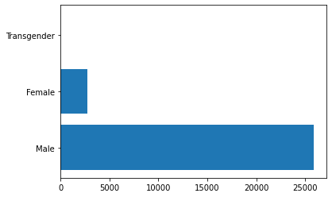

```python
kyd.print_info_variable(df, "Subject's gender")
```

Apart from the missing values, this variable does not have any other problem.

#### Variable "**Subject's race**"

```
Type of the variable : object
Number of distinct values : 7
Percentage of distinct values : 0.03 %
Number of missing values : 1
Percentage of missing values : 0.00 %
Min string length : 14.0
Mean string length : 14.0
Max string length : 23.0
Categories of the distinct values
European-American/White    9284
Race unspecified           8849
African-American/Black     6109
Hispanic/Latino            3705
Asian/Pacific Islander      434
Native American/Alaskan     286
Middle Eastern               49
Name: Subject's race, dtype: int64
```

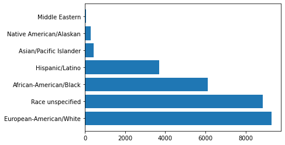

```python
kyd.print_info_variable(data, 'Subject\'s race')
```

"**Race Unspecified**" are actually not recorded so we have many missing values, we are dealing here with **Data Completeness** quality dimension.

#### Variable "**Date of injury resulting in death (month/day/year)**"

```python
kyd.print_info_variable(data, "Date of injury resulting in death (month/day/year)")
```

```
Type of the variable : datetime64[ns]
Number of distinct values : 7268
Percentage of distinct values : 25.31 %
Number of missing values : 0
Percentage of missing values : 0.00 %
```

```python
df[df["Date of injury resulting in death (month/day/year)"].dt.year > 2021]
```

|  | Unique ID | Subject's name | Subject's age | Subject's gender | Subject's race | Subject's race with imputations | Imputation probability | URL of image of deceased | Date of injury resulting in death (month/day/year) | Location of injury (address) | ... | Agency responsible for death | Cause of death | A brief description of the circumstances surrounding the death | Dispositions/Exclusions INTERNAL USE, NOT FOR ANALYSIS | Intentional Use of Force (Developing) | Link to news article or photo of official document | Symptoms of mental illness? INTERNAL USE, NOT FOR ANALYSIS | Date&Description | Unique identifier (redundant) | Date (Year) |
| --- | --- | --- | --- | --- | --- | --- | --- | --- | --- | --- | --- | --- | --- | --- | --- | --- | --- | --- | --- | --- | --- |
| 28716 | NaN | This is a spacer for Fatal Encounters use. | NaN | NaN | NaN | NaN | NaN | NaN | 2100-12-31 | This row is a spacer for Fatal Encounters use. | ... | NaN | NaN | NaN | NaN | NaN | https://www.fatalencounters.org | NaN | 12/31/2100: https://www.fatalencounters.org | NaN | 2100 |

1 rows × 27 columns

We are currently in 2021 so it is an issue to have date which year is above the on-going year. By displaying the concerned row, it is not about a person so there is no issue with this column as well.

#### Variable "**Imputation probability**"

```python
kyd.print_info_variable(data, "Imputation probability")
```

```
Type of the variable : object
Number of distinct values : 7240
Percentage of distinct values : 25.22 %
Number of missing values : 223
Percentage of missing values : 0.78 %
Min string length : 1.0
Mean string length : 1.0
Max string length : 19.0
```

A probability should be a number between 0 and 1 but here it looks like we have other values. Let's display the first 5 rows.

```python
data["Imputation probability"].head()
```

```
0    Not imputed
1    Not imputed
2    Not imputed
3    Not imputed
4    Not imputed
Name: Imputation probability, dtype: object
```

From the output above, we can see that there are string values in a column that is supposed to be only between 0 and 1. Let's see the other possible values present

```python
other_values = {}
for x in df["Imputation probability"]:
    length = len(str(x))
    other_values[length] = x
# Print the other formats
print("Key : Value \n-----------")
for key, value in other_values.items():
    print(f"{key} : {value}")
```

```
Key : Value
-----------
11 : Not imputed
3 : nan
19 : Race not determined
10 : 0.98931414
9 : 0.8101936
1 : 1
8 : 0.950832
```

Apart from the **nan** value, the other possible values are "**Not imputed**" and "**Race not determined**". The quality dimension concerned here is **Data Consistency**

#### Variable "**Subject's name**"

```python
kyd.print_info_variable(data, "Subject's name")
```

```
Type of the variable : object
Number of distinct values : 27309
Percentage of distinct values : 95.10 %
Number of missing values : 0
Percentage of missing values : 0.00 %
Min string length : 4
Mean string length : 4
Max string length : 82
```

We have about 95% of distinct values. That means we have duplicated values. Let's display them

```python
data[data["Subject's name"].duplicated()].head(2)
```

|  | Unique ID | Subject's name | Subject's age | Subject's gender | Subject's race | Subject's race with imputations | Imputation probability | URL of image of deceased | Date of injury resulting in death (month/day/year) | Location of injury (address) | ... | A brief description of the circumstances surrounding the death | Dispositions/Exclusions INTERNAL USE, NOT FOR ANALYSIS | Intentional Use of Force (Developing) | Link to news article or photo of official document | Symptoms of mental illness? INTERNAL USE, NOT FOR ANALYSIS | Video | Date&Description | Unique ID formula | Unique identifier (redundant) | Date (Year) |
| --- | --- | --- | --- | --- | --- | --- | --- | --- | --- | --- | --- | --- | --- | --- | --- | --- | --- | --- | --- | --- | --- |
| 24 | 9.0 | Name withheld by police | 28 | Male | Race unspecified | Race unspecified | Race not determined | NaN | 2000-01-07 | Walters Road | ... | An unidentified Lucasville man killed himself ... | Suicide | Suicide | https://docs.google.com/document/d/1sF4PTZ__n7... | No | NaN | 1/7/2000: An unidentified Lucasville man kille... | NaN | 9.0 | 2000 |
| 55 | 28.0 | Name withheld by police | 34 | Male | Race unspecified | Race unspecified | Race not determined | NaN | 2000-01-21 | 4700 block NW Gleason Rd. | ... | Police shot and killed an unidentified 34-year... | Unreported | Deadly force | https://drive.google.com/file/d/0B62PuBu1vKRLS... | Unknown | NaN | 1/21/2000: Police shot and killed an unidentif... | NaN | 28.0 | 2000 |

2 rows × 29 columns

The duplicated value is "**Name withheld by police**" so it does not concern any person. Let's see if there are other duplicated values

```python
data[data["Subject's name"] != "Name withheld by police"].duplicated().sum()
```

```
0
```

With the output above, we can conclude that there is no issue with this variable.

#### Variable "**Full Address**"

```python
kyd.print_info_variable(data, "Full Address")
```

```
Type of the variable : object
Number of distinct values : 27114
Percentage of distinct values : 94.42 %
Number of missing values : 1
Percentage of missing values : 0.00 %
Min string length : 2.0
Mean string length : 2.0
Max string length : 103.0
```

The data concerns the USA so a full address should be composed of **Street, City, State, Zip Code** at least. From the output above, we can see at least one address has only 2 characters so there is some information missing. Let's look at this in details.

```python
# Get the incorrect full addresses
incorrect_full_addresses = data[data["Full Address"].str.len() == 2]["Full Address"]
# Display the first two
print("Incorrect addresses")
print(incorrect_full_addresses[:2])
# Count the total
print(f"\nTotal : {len(incorrect_full_addresses)}")
```

```
Incorrect addresses
4585    KS
7685    KS
Name: Full Address, dtype: object

Total : 8
```

These addresses are incomplete. The data quality dimension issue here is **Data Accuracy**

#### Variable "**Intentional Use of Force (Developing)**"

```
Type of the variable : object
Number of distinct values : 11
Percentage of distinct values : 0.04 %
Number of missing values : 1
Percentage of missing values : 0.00 %
Min string length : 2.0
Mean string length : 12.27
Max string length : 24.0
Categories of the distinct values
Deadly force                17353
Vehicle/Pursuit              5426
Suicide                      2985
Less-than-lethal force       1660
No                            805
Pursuit                       354
Vehicle                        82
Undetermined                   48
Intentional use of force        1
Np                              1
Unknown                         1
Name: Intentional Use of Force (Developing), dtype: int64
```

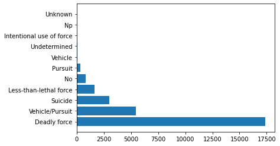

```python
kyd.print_info_variable(data, "Intentional Use of Force (Developing)")
```

#### Variable ""**Dispositions/Exclusions INTERNAL USE, NOT FOR ANALYSIS**""

```python
kyd.print_info_variable(data, "Dispositions/Exclusions INTERNAL USE, NOT FOR ANALYSIS")
```

```
Type of the variable : object
Number of distinct values : 106
Percentage of distinct values : 0.37 %
Number of missing values : 1
Percentage of missing values : 0.00 %
Min string length : 7.0
Mean string length : 13.53
Max string length : 82.0
```

#### Variable "**Cause of death**"

```
Type of the variable : object
Number of distinct values : 14
Percentage of distinct values : 0.05 %
Number of missing values : 1
Percentage of missing values : 0.00 %
Min string length : 5.0
Mean string length : 7.56
Max string length : 33.0
Categories of the distinct values
Gunshot                              20355
Vehicle                               5899
Tasered                                917
Medical emergency                      381
Asphyxiated/Restrained                 279
Drug overdose                          178
Drowned                                176
Beaten/Bludgeoned with instrument      175
Undetermined                           103
Fell from a height                      76
Other                                   57
Stabbed                                 48
Burned/Smoke inhalation                 37
Chemical agent/Pepper spray             35
Name: Cause of death, dtype: int64
```

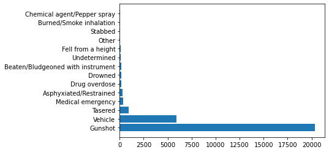

```python
kyd.print_info_variable(data, "Cause of death")
```

#### Variable "**Symptoms of mental illness? INTERNAL USE, NOT FOR ANALYSIS**"

```
Type of the variable : object
Number of distinct values : 4
Percentage of distinct values : 0.02 %
Number of missing values : 62
Percentage of missing values : 0.22 %
Min string length : 2.0
Mean string length : 3.82
Max string length : 19.0
Categories of the distinct values
No                     19156
Unknown                 4752
Yes                     3267
Drug or alcohol use     1480
Name: Symptoms of mental illness? INTERNAL USE, NOT FOR ANALYSIS, dtype: int64
```

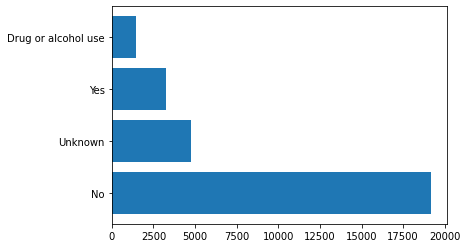

```python
kyd.print_info_variable(data, "Symptoms of mental illness? INTERNAL USE, NOT FOR ANALYSIS")
```

According to the name of the variable, we should not have specific values. This falls into the **Consistency** quality dimension issue

#### Variable "**Location of death (state)**"

```python
kyd.print_info_variable(data, "Location of death (state)")
```

```
Type of the variable : object
Number of distinct values : 51
Percentage of distinct values : 0.18 %
Number of missing values : 1
Percentage of missing values : 0.00 %
Min string length : 2.0
Mean string length : 2.00
Max string length : 2.0
```

According to the statistics, we can conclude that all the values have a length of 2. That means the abbreviation is used instead of the actual values and it is hard to recognize some states because some abbreviations are not intuitive. This is a **Data Accuracy** quality dimension problem.

### Quality dimensions

We have identified three (3) data quality dimensions problems : **Data Consistency** with the "*Subject's age*" and "*Imputation probability*" variables, **Data Accuracy** with the "*Full Address*" and "*Location of death (state)*" variables and **Data Completeness** with the "*Subject's race*" variable and many others. We have looked for other data quality dimensions such as **Data Uniqueness** too but there are no duplicated subjects in the dataset.

## Methodology

In this section, we are going to indicate the quality goals, questions, related quality factors and metrics.

### Data consistency with "*Subject's age*"

**Goal** : Standardize the age so that all the values have consistency  
**Question** : Which kind of formats are present in this variable ?  
**Quality factor** : Domain integrity  
**Metric** : Ratio of ages that are not in the expected format

**Quality Plan** :

- Detect the ages that are not in the correct format
- Define a methodology to correct most of the values which are in the wrong format

### Data Accuracy with "*Location of death (state)*"

**Goal** : Replace all the abbreviations with the real values  
**Question** : How many values are not accurate ?  
**Quality factor** : Precision  
**Metric** : Average length of the values

**Quality Plan** :

- Use a dataset which have both the real values and the abbreviation
- Join this dataset with ours and replace the states with their real values

### Data Completeness with "*Subject's race*"

**Goal** : Replace the null values (Race unspecified)  
**Question** : How many values are missing for the subject's race ?  
**Quality factor** : Density  
**Metric** : Ratio of null values

**Quality Plan** :

- Use the "**Imputation probability**" variable with a threshold
- If the condition is satisfied, replace the null value with the "**Subject's race with imputation**" value